# Linear and Non-Linear Models (31010) Week 5 Workshop

Yuri Balasanov,iLykei, 2016

```r
suppressWarnings(library(faraway))
suppressWarnings(library(MASS))
suppressWarnings(library(AER))
suppressWarnings(library(pscl))
```

# 1 Example from slide 8 in the Lecture Notes.

Web server is currently registering a Poisson flow of visitors with average rate 15 visits per hour.

1. What is the probability of receiving at least 10 visits in the next 30 minutes?

(Skipped Code)

```
## [1] 0.2235924
```

2. What is the probability of receiving more than 10 visits in the next hour?

(Skipped Code)

```
## [1] 0.8815356
```

# 2 Poisson Regression

Poisson regression is based on log link, i.e. log of intensity of Poisson process is the response of linear model:

$$\ln(\lambda)=\beta_0 +\beta_1 x_1 + \ldots + \beta_p x_p.$$
Then probability distribution of counts is given by
$$P(N_p=k;\lambda)=\frac{e^{-\lambda} \lambda^k}{k!},$$
where
$$\lambda=e^{\eta_i}=e^{\beta_0 +\beta_1 x_1 + \ldots + \beta_p x_p}$$

## 2.1 Data

Data set `gala` contains counts of plant species on each of 30 Galapagos Islands and the number that are endemic.  
There are also 5 geographic variables for each island.

```r
data(gala)
head(gala)
```

```
##              Species Endemics  Area Elevation Nearest Scruz Adjacent
## Baltra            58       23 25.09       346     0.6   0.6     1.84
## Bartolome         31       21  1.24       109     0.6  26.3   572.33
## Caldwell           3        3  0.21       114     2.8  58.7     0.78
## Champion          25        9  0.10        46     1.9  47.4     0.18
## Coamano            2        1  0.05        77     1.9   1.9   903.82
## Daphne.Major      18       11  0.34       119     8.0   8.0     1.84
```

Remove the endemic column.

```r
gala <- gala[,-2]
```

## 2.2 Linear regression

Fit linear regression and check the residuals.

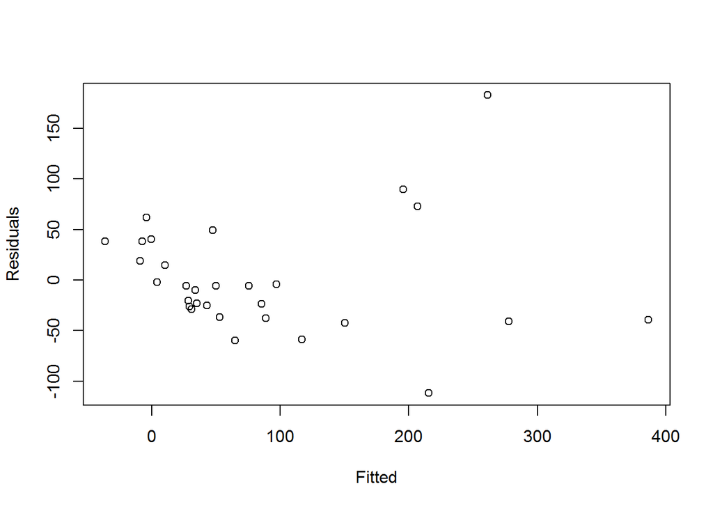

```r
modl <- lm(Species ~ . , gala)
plot(predict(modl),residuals(modl),xlab="Fitted",ylab="Residuals")
```

The plot shows non-constant variance.  
Use the square root transformation to stabilize the variance.

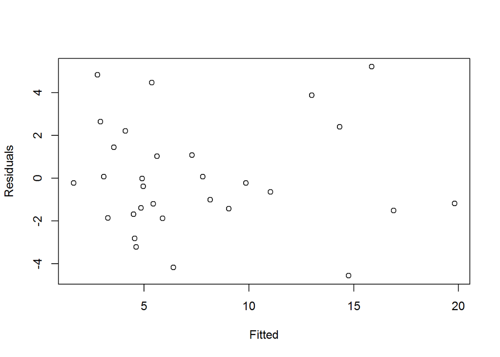

```r
modt <- lm(sqrt(Species) ~ . , gala)
plot(predict(modt),residuals(modt),xlab="Fitted",ylab="Residuals")
```

Now points on the plot do not cluster as much.

```r
summary(modt)
```

```
##
## Call:
## lm(formula = sqrt(Species) ~ ., data = gala)
##
## Residuals:
##     Min      1Q  Median      3Q     Max
## -4.5572 -1.4969 -0.3031  1.3527  5.2110
##
## Coefficients:
##               Estimate Std. Error t value Pr(>|t|)
## (Intercept)  3.3919243  0.8712678   3.893 0.000690 ***
## Area        -0.0019718  0.0010199  -1.933 0.065080 .
## Elevation    0.0164784  0.0024410   6.751 5.55e-07 ***
## Nearest      0.0249326  0.0479495   0.520 0.607844
## Scruz       -0.0134826  0.0097980  -1.376 0.181509
## Adjacent    -0.0033669  0.0008051  -4.182 0.000333 ***
## ---
## Signif. codes:  0 '***' 0.001 '**' 0.01 '*' 0.05 '.' 0.1 ' ' 1
##
## Residual standard error: 2.774 on 24 degrees of freedom
## Multiple R-squared:  0.7827, Adjusted R-squared:  0.7374
## F-statistic: 17.29 on 5 and 24 DF,  p-value: 2.874e-07
```

The fit looks pretty good, according to the determination coefficient.

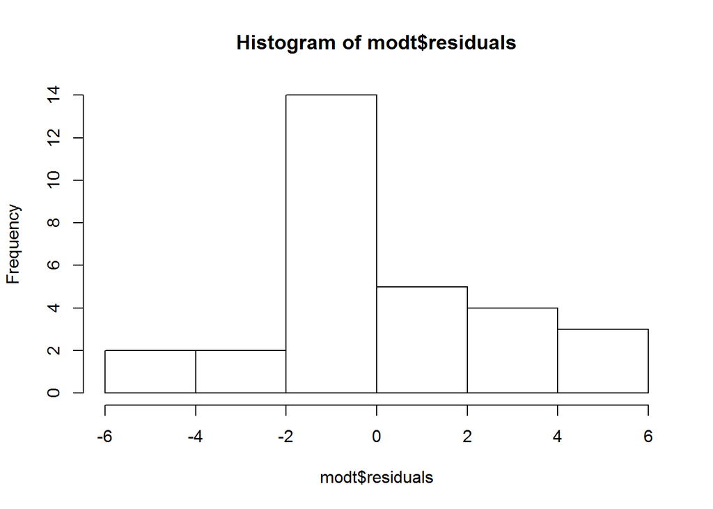

```r
hist(modt$residuals)
```

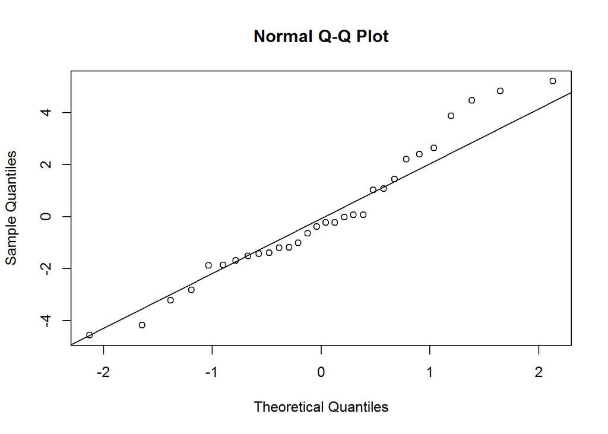

```r
qqnorm(modt$residuals)
qqline(modt$residuals)
```

The Gaussian assumption is in question.  
See if it is possible to keep the nature of the data untransformed (counts, rather than square root of them) and find a better explanation of the data.

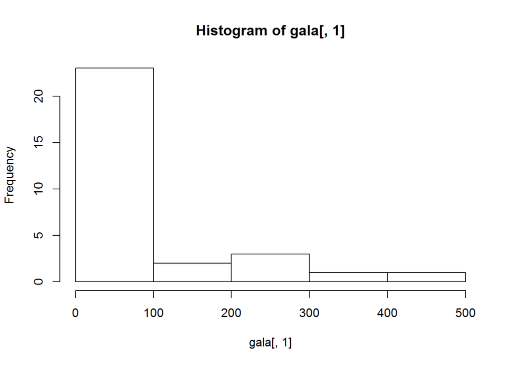

```r
hist(gala[,1])
```

```r
(poisParam<-fitdistr(gala[,1],"poisson"))
```

```
##     lambda
##   85.23333
##  ( 1.68556)
```

```r
ks.test(gala[,1],"ppois",poisParam$estimate)
```

```
##
##  One-sample Kolmogorov-Smirnov test
##
## data:  gala[, 1]
## D = 0.66154, p-value = 7.893e-12
## alternative hypothesis: two-sided
```

The fit is not great for Poisson model, but continue with the example as in the book.

## 2.3 Poisson regression

Fit Poisson regression.

Main formula to remember is:

$$\eta_i=\ln(\lambda_i)=\ln(\mu_i).$$

```r
modp <- glm(Species ~ .,family=poisson,gala)
summary(modp)
```

```
##
## Call:
## glm(formula = Species ~ ., family = poisson, data = gala)
##
## Deviance Residuals:
##     Min       1Q   Median       3Q      Max
## -8.2752  -4.4966  -0.9443   1.9168  10.1849
##
## Coefficients:
##               Estimate Std. Error z value Pr(>|z|)
## (Intercept)  3.155e+00  5.175e-02  60.963  < 2e-16 ***
## Area        -5.799e-04  2.627e-05 -22.074  < 2e-16 ***
## Elevation    3.541e-03  8.741e-05  40.507  < 2e-16 ***
## Nearest      8.826e-03  1.821e-03   4.846 1.26e-06 ***
## Scruz       -5.709e-03  6.256e-04  -9.126  < 2e-16 ***
## Adjacent    -6.630e-04  2.933e-05 -22.608  < 2e-16 ***
## ---
## Signif. codes:  0 '***' 0.001 '**' 0.01 '*' 0.05 '.' 0.1 ' ' 1
##
## (Dispersion parameter for poisson family taken to be 1)
##
##     Null deviance: 3510.73  on 29  degrees of freedom
## Residual deviance:  716.85  on 24  degrees of freedom
## AIC: 889.68
##
## Number of Fisher Scoring iterations: 5
```

The fitted model has the form

$$\ln{\lambda_i}=\eta_i=\beta_0+\beta_1 x_{1,i}+\beta_2 x_{2,i}+\beta_3 x_{3,i}+\beta_4 x_{4,i}+\beta_5 x_{5,i},$$
where $\lambda_i=E[Y_i]$.

Prediction of $\eta_i$ is done by

```r
predict(modp)
```

```
##       Baltra    Bartolome     Caldwell     Champion      Coamano
##     4.365952     3.015678     3.247365     3.063640     2.834065
## Daphne.Major Daphne.Minor       Darwin         Eden      Enderby
##     3.599651     3.468252     2.390464     3.395518     3.287517
##     Espanola   Fernandina     Gardner1     Gardner2     Genovesa
##     3.327240     4.474425     2.767493     3.643403     3.219898
##      Isabela     Marchena       Onslow        Pinta       Pinzon
##     5.915720     4.021029     3.010313     5.359429     4.799313
##   Las.Plazas       Rabida SanCristobal  SanSalvador    SantaCruz
##     3.471842     3.971420     5.388256     5.916144     5.694668
##      SantaFe   SantaMaria      Seymour      Tortuga         Wolf
##     4.108928     5.063641     3.608058     3.570142     2.894143
```

```r
predict(modp,type="link")
```

```
##       Baltra    Bartolome     Caldwell     Champion      Coamano
##     4.365952     3.015678     3.247365     3.063640     2.834065
## Daphne.Major Daphne.Minor       Darwin         Eden      Enderby
##     3.599651     3.468252     2.390464     3.395518     3.287517
##     Espanola   Fernandina     Gardner1     Gardner2     Genovesa
##     3.327240     4.474425     2.767493     3.643403     3.219898
##      Isabela     Marchena       Onslow        Pinta       Pinzon
##     5.915720     4.021029     3.010313     5.359429     4.799313
##   Las.Plazas       Rabida SanCristobal  SanSalvador    SantaCruz
##     3.471842     3.971420     5.388256     5.916144     5.694668
##      SantaFe   SantaMaria      Seymour      Tortuga         Wolf
##     4.108928     5.063641     3.608058     3.570142     2.894143
```

And prediction of $\lambda$ is done by either of the two methods.

```r
predict(modp,type="response")
```

```
##       Baltra    Bartolome     Caldwell     Champion      Coamano
##     78.72434     20.40293     25.72248     21.40533     17.01448
## Daphne.Major Daphne.Minor       Darwin         Eden      Enderby
##     36.58545     32.08061     10.91856     29.83009     26.77630
##     Espanola   Fernandina     Gardner1     Gardner2     Genovesa
##     27.86135     87.74415     15.91867     38.22167     25.02558
##      Isabela     Marchena       Onslow        Pinta       Pinzon
##    370.82105     55.75848     20.29374    212.60359    121.42695
##   Las.Plazas       Rabida SanCristobal  SanSalvador    SantaCruz
##     32.19599     53.05982    218.82132    370.97834    297.27800
##      SantaFe   SantaMaria      Seymour      Tortuga         Wolf
##     60.88144    158.16532     36.89432     35.52164     18.06800
```

```r
exp(predict(modp))
```

```
##       Baltra    Bartolome     Caldwell     Champion      Coamano
##     78.72434     20.40293     25.72248     21.40533     17.01448
## Daphne.Major Daphne.Minor       Darwin         Eden      Enderby
##     36.58545     32.08061     10.91856     29.83009     26.77630
##     Espanola   Fernandina     Gardner1     Gardner2     Genovesa
##     27.86135     87.74415     15.91867     38.22167     25.02558
##      Isabela     Marchena       Onslow        Pinta       Pinzon
##    370.82105     55.75848     20.29374    212.60359    121.42695
##   Las.Plazas       Rabida SanCristobal  SanSalvador    SantaCruz
##     32.19599     53.05982    218.82132    370.97834    297.27800
##      SantaFe   SantaMaria      Seymour      Tortuga         Wolf
##     60.88144    158.16532     36.89432     35.52164     18.06800
```

Finally, predicted probabilities of counts can be calculated as, for example for count zero:

```r
coun<-0
dpois(coun,predict(modp,type="response"))
```

```
##        Baltra     Bartolome      Caldwell      Champion       Coamano
##  6.463305e-35  1.377592e-09  6.743272e-12  5.055737e-10  4.080435e-08
##  Daphne.Major  Daphne.Minor        Darwin          Eden       Enderby
##  1.291639e-16  1.168342e-14  1.811874e-05  1.109061e-13  2.350717e-12
##      Espanola    Fernandina      Gardner1      Gardner2      Genovesa
##  7.942721e-13  7.819847e-39  1.220704e-07  2.515004e-17  1.353720e-11
##       Isabela      Marchena        Onslow         Pinta        Pinzon
## 9.004551e-162  6.086967e-25  1.536527e-09  4.649779e-93  1.840537e-53
##    Las.Plazas        Rabida  SanCristobal   SanSalvador     SantaCruz
##  1.041017e-14  9.045067e-24  9.270614e-96 7.694016e-162 7.830816e-130
##       SantaFe    SantaMaria       Seymour       Tortuga          Wolf
##  3.626819e-27  2.040207e-69  9.484217e-17  3.742375e-16  1.422872e-08
```

We see that all predictors are significant.  
However, residual deviance of 716.85 with 24 degrees of freedom do not suggest a good fit.

These data may not be described well by the Poisson regression.

**There may be overdispersion.**

## 2.4 Methods for Testing Over-Dispersion

There are several ways of testing for overdispersion.

### 2.4.1 A quick and rough method.

Look at the output of `glm()` and compare the residual deviance with the number of degrees of freedom.  
If the assumed model is correct deviance is asymptotically distributed as Chi-squared ($X^2$) with degrees of freedom $n-k$ where n is the number of observations and k is the number of parameters.  
For Chi-squared distribution the mean is the number of degrees of freedom $n-k$.  
If the residual deviance returned by `glm()` is greater than $n-k$ then it might be a sign of over-dispersion.

Test the method on simulated Poisson data.

```r
Test.Deviance.Overdispersion.Poisson<-function(Sample.Size,Parameter.Lambda){
  my.Sample<-rpois(Sample.Size,Parameter.Lambda)
  Model<-glm(my.Sample~1,family=poisson)
  Dev<-Model$deviance
  Deg.Fred<-Model$df.residual
  ((Dev-Deg.Fred)/sqrt(2*Deg.Fred)>-1.96)&((Dev-Deg.Fred)/sqrt(2*Deg.Fred)<1.96)
}
set.seed(7324)
Test.Deviance.Overdispersion.Poisson(100,1)
```

```
## [1] TRUE
```

The function simulates a sample from Poisson distribution, estimates parameter $\lambda$ which is simultaneously the mean value and the variance, then it checks if $\frac{Deviance-Deg.Freedom}{\sqrt{2*Deg.Freedom}}$ belongs to the interval $(-1.96,1.96)$.  
If yes, the result is `TRUE`. Otherwise it is `FALSE`.

Now repeat the call of the function 300 times to see how many times it returns `TRUE` and how many times `FALSE`.

```r
sum(replicate(300,Test.Deviance.Overdispersion.Poisson(100,1)))
```

```
## [1] 257
```

Note that the number of passes is lower than expected for 95% confidence interval.  
This means that the test has a tendency to detect overdispersion when it is not present.

The estimate of the parameter $\lambda$ given by `glm()` is $e^{Coefficient}$:

```r
exp(glm(rpois(1000,2)~1,family=poisson)$coeff)
```

```
## (Intercept)
##       2.016
```

Perform the same test on negative binomial data (we know there will be overdispersion there).

```r
Test.Deviance.Overdispersion.NBinom<-function(Sample.Size,Parameter.prob){
  my.Sample<-rnbinom(Sample.Size,2,Parameter.prob)
  Model<-glm(my.Sample~1,family=poisson)
  Dev<-Model$deviance
  Deg.Fred<-Model$df.residual
  ((Dev/Deg.Fred-1)/sqrt(2/Deg.Fred)>-1.96)&((Dev/Deg.Fred-1)/sqrt(2/Deg.Fred)<=1.96)
}
sum(replicate(300,Test.Deviance.Overdispersion.NBinom(100,.2)))
```

```
## [1] 0
```

We see that the over-dispersed negative binomial distribution sample rarely or never passes the test.

### 2.4.2 Regression test by Cameron-Trivedi

The test implemented in `AER` is described in Cameron, A.C. and Trivedi, P.K. (1990). Regression-based Tests for Over-dispersion in the Poisson Model. Journal of Econometrics, 46, 347–364.

In a Poisson model, the mean is $E(Y)=\lambda$ and the variance is $V(Y)=\lambda$ as well.  
The test has a null hypothesis $c=0$ where $Var(Y)=\lambda+c∗f(\lambda)$, $c<0$ means under-dispersion and $c>0$ means over-dispersion.  
The function f(.) is some monotonic function (linear as default or quadratic).  
The test statistic used is a t statistic which is asymptotically standard normal under the null.

```r
suppressWarnings(library(AER))
```

```r
dispersiontest(glm(rpois(100,1)~1,family="poisson"),alternative="two.sided")
```

```
##
##  Dispersion test
##
## data:  glm(rpois(100, 1) ~ 1, family = "poisson")
## z = -0.27171, p-value = 0.7858
## alternative hypothesis: true dispersion is not equal to 1
## sample estimates:
## dispersion
##  0.9595238
```

```r
dispersiontest(glm(rnbinom(100,size=20,prob=.7)~1,family="poisson"),alternative="two.sided")
```

```
##
##  Dispersion test
##
## data:  glm(rnbinom(100, size = 20, prob = 0.7) ~ 1, family = "poisson")
## z = 3.5261, p-value = 0.0004217
## alternative hypothesis: true dispersion is not equal to 1
## sample estimates:
## dispersion
##   1.791342
```

In the first case the hypothesis $H_0:$ “dispersion=1” cannot be rejected.  
In the second case it needs to be rejected with 5% level.

### 2.4.3 Test against Negative Binomial Distribution

The null hypothesis of this test is that the distribution is Poisson as particular case of Negative binomial against Negative Binomial.

The references are:  
A. Colin Cameron and Pravin K. Trivedi (1998) Regression analysis of count data. New York: Cambridge University Press.

Lawless, J. F. (1987) Negative Binomial and Mixed Poisson Regressions. The Canadian Journal of Statistics. 15:209-225.

Required packages are `MASS` (to create a negative binomial object with `glm.nb`) and `pscl`, which contains the test function `odTest()`.

```r
suppressWarnings(library(pscl))
```

Apply `glm.nb()` from `MASS` to fit a negative binomial model.  
Then use `odTest()` from `pscl` to test if the data can be described by Poisson distribution (no over-dispersion) or not (over-dispersion).

```r
set.seed(958)
NB.model.pois<-suppressWarnings(glm.nb(rpois(100,2)~1))
names(NB.model.pois)
```

```
##  [1] "coefficients"      "residuals"         "fitted.values"
##  [4] "effects"           "R"                 "rank"
##  [7] "qr"                "family"            "linear.predictors"
## [10] "deviance"          "aic"               "null.deviance"
## [13] "iter"              "weights"           "prior.weights"
## [16] "df.residual"       "df.null"           "y"
## [19] "converged"         "boundary"          "th.warn"
## [22] "terms"             "call"              "model"
## [25] "theta"             "SE.theta"          "twologlik"
## [28] "method"            "control"
```

```r
NB.model.pois
```

```
##
## Call:  glm.nb(formula = rpois(100, 2) ~ 1, init.theta = 32475.99925,
##     link = log)
##
## Coefficients:
## (Intercept)
##      0.8587
##
## Degrees of Freedom: 99 Total (i.e. Null);  99 Residual
## Null Deviance:       96.09
## Residual Deviance: 96.09     AIC: 353.4
```

```r
summary(NB.model.pois)
```

```
##
## Call:
## glm.nb(formula = rpois(100, 2) ~ 1, init.theta = 32475.99925,
##     link = log)
##
## Deviance Residuals:
##     Min       1Q   Median       3Q      Max
## -2.1725  -1.0013  -0.2407   0.3996   1.9791
##
## Coefficients:
##             Estimate Std. Error z value Pr(>|z|)
## (Intercept)   0.8587     0.0651   13.19   <2e-16 ***
## ---
## Signif. codes:  0 '***' 0.001 '**' 0.01 '*' 0.05 '.' 0.1 ' ' 1
##
## (Dispersion parameter for Negative Binomial(32476) family taken to be 1)
##
##     Null deviance: 96.094  on 99  degrees of freedom
## Residual deviance: 96.094  on 99  degrees of freedom
## AIC: 353.38
##
## Number of Fisher Scoring iterations: 1
##
##
##               Theta:  32476
##           Std. Err.:  591795
## Warning while fitting theta: iteration limit reached
##
##  2 x log-likelihood:  -349.376
```

The negative binomial model is estimated with deviance 96.0937388 and degrees of freedom 99. The AIC value is 353.3762775.

Parameter `Theta` in the `summary()` shows the amount of overdispersion.  
If $\mu$ is the mean value of counts according to negative binomial distribution then variance is $\mu+\frac{\mu^2}{\theta}$.  
So, if $\theta$ is very large then both mean and variance are equal to $\mu$, like in Poisson distribution.  
But if $\theta$ is small then variance is greater than $\mu$ which means overdispersion relative to the Poisson distribution.  
See [discussion](http://stats.stackexchange.com/questions/10419/what-is-theta-in-a-negative-binomial-regression-fitted-with-r) for more information.

The estimated parameter of the model is:

```r
NB.model.pois$coefficients
```

```
## (Intercept)
##   0.8586616
```

To find the intensity of the simulated Poisson process take exponent of the linear predictor:

```r
unique(exp(predict(NB.model.pois)))
```

```
## [1] 2.36
```

```r
unique(predict(NB.model.pois,type="response"))
```

```
## [1] 2.36
```

```r
exp(NB.model.pois$coefficients)
```

```
## (Intercept)
##        2.36
```

Use the model to test for overdispersion.

```r
odTest.pois<-odTest(NB.model.pois)
```

```
## Likelihood ratio test of H0: Poisson, as restricted NB model:
## n.b., the distribution of the test-statistic under H0 is non-standard
## e.g., see help(odTest) for details/references
##
## Critical value of test statistic at the alpha= 0.05 level: 2.7055
## Chi-Square Test Statistic =  0.8309 p-value = 0.181
```

With high p-value the null hypothesis cannot be rejected.

Repeat the same steps with simulated negative binomial distribution with the same mean value.

```r
set.seed(958)
NB.model<-glm.nb(rnbinom(100,size=2,prob=.5)~1)
NB.model
```

```
##
## Call:  glm.nb(formula = rnbinom(100, size = 2, prob = 0.5) ~ 1, init.theta = 2.358722057,
##     link = log)
##
## Coefficients:
## (Intercept)
##      0.8242
##
## Degrees of Freedom: 99 Total (i.e. Null);  99 Residual
## Null Deviance:       111.9
## Residual Deviance: 111.9     AIC: 397.5
```

```r
summary(NB.model)
```

```
##
## Call:
## glm.nb(formula = rnbinom(100, size = 2, prob = 0.5) ~ 1, init.theta = 2.358722057,
##     link = log)
##
## Deviance Residuals:
##     Min       1Q   Median       3Q      Max
## -1.7862  -0.7215  -0.1365   0.3166   2.9127
##
## Coefficients:
##             Estimate Std. Error z value Pr(>|z|)
## (Intercept)  0.82418    0.09287   8.874   <2e-16 ***
## ---
## Signif. codes:  0 '***' 0.001 '**' 0.01 '*' 0.05 '.' 0.1 ' ' 1
##
## (Dispersion parameter for Negative Binomial(2.3587) family taken to be 1)
##
##     Null deviance: 111.93  on 99  degrees of freedom
## Residual deviance: 111.93  on 99  degrees of freedom
## AIC: 397.54
##
## Number of Fisher Scoring iterations: 1
##
##
##               Theta:  2.359
##           Std. Err.:  0.731
##
##  2 x log-likelihood:  -393.539
```

```r
exp(NB.model$coefficients)
```

```
## (Intercept)
##        2.28
```

```r
odTest.pois<-odTest(NB.model)
```

```
## Likelihood ratio test of H0: Poisson, as restricted NB model:
## n.b., the distribution of the test-statistic under H0 is non-standard
## e.g., see help(odTest) for details/references
##
## Critical value of test statistic at the alpha= 0.05 level: 2.7055
## Chi-Square Test Statistic =  18.1596 p-value = 1.016e-05
```

This time the null hypothesis is rejected signaling overdispersion.

### 2.4.4 Prediction by negative binomial regression

Prediction by negative binomial model is done as either

$$P(N_{NB}=k)=N_{nbinom}(k;p,s),$$
or
$$P(N_{NB}=k)=N_{nbinom}(k;\mu,s),$$
where

- Parameter $\mu=e^{\eta_i}$ is the mean value of the predicted count, $\mu=E[N_{NB}]$; $\mu$ is the response of the linear model and can be calculated from `glm.nb` object as `predict(fit,type="response")`
- Parameter $p=\frac{s}{\mu+s}$
- Parameter $s$ is the size of negative binomial distribution; it can be extracted from `glm.nb` object as estimate of parameter `\theta`: `fit$theta`.

For example, probability of count equal to zero is calculated both ways using `glm.nb` object as:

```r
(theta<-NB.model$theta)
```

```
## [1] 2.358722
```

```r
coun<-0
mu<-unique(predict(NB.model,new.data=data.frame(0),type="response"))
(prob.coun.1<-unique(dnbinom(coun,mu=mu,size=theta)))
```

```
## [1] 0.2028581
```

```r
p<-theta/(mu+theta)
(prob.coun.2<-dnbinom(coun,p=p,size=theta))
```

```
## [1] 0.2028581
```

Probabilities are constant vectors because this simulated model does not have any predictors, only intercept.

# 3 Examples of Poisson, Negative Binomial and Zero-Augmented Regressions

## 3.1 Wave Soldering

[Wave soldering](https://en.wikipedia.org/wiki/Wave_soldering) is a bulk soldering process used in the manufacture of printed circuit boards. The circuit board is [passed over a pan of molten solder](http://ilykei.com/api/fileProxy/documents%2FMScA%20Linear%20and%20Non-Linear%20Models%2031010%2FMScA%2031010%20Lecture%205%2FwaveSoldering1.jpeg) in which a pump produces an upwelling of solder that looks like a standing wave. As the circuit board makes contact with this wave, the components become soldered to the board.

In this example AT&T experimented with 5 parameters of wave soldering process for mounting components on printed circuit boards.

```r
data(solder)
head(solder)
```

```
##   Opening Solder Mask PadType Panel skips
## 1       L  Thick A1.5      W4     1     0
## 2       L  Thick A1.5      W4     2     0
## 3       L  Thick A1.5      W4     3     0
## 4       L  Thick A1.5      D4     1     0
## 5       L  Thick A1.5      D4     2     0
## 6       L  Thick A1.5      D4     3     0
```

The output variable `skips` is the count of [solder skips](http://ilykei.com/api/fileProxy/documents%2FMScA%20Linear%20and%20Non-Linear%20Models%2031010%2FMScA%2031010%20Lecture%205%2FSolderSkip.jpg).

The number of elements mounted by soldering is large enough to assume Poisson regression.

### 3.1.1 Poisson regression

Fit Poisson regression

```r
modp <- glm(skips ~ . , family=poisson, data=solder)
(Dev<-deviance(modp))
```

```
## [1] 1829.002
```

```r
(Deg.Fred<-df.residual(modp))
```

```
## [1] 882
```

```r
(aicComplete<-modp$aic)
```

```
## [1] 3967.552
```

Deviance of 1829 on 882 degrees of freedom does not look like a good fit.  
Check for overdispersion using the 3 methods to confirm that.

(Skipped Code)

```
## [1] "Method 1"
```

```
## [1] 20.58768 24.50768
```

```
## [1] "Method 2"
```

```
##  statistic.z      p.value
## 9.244411e+00 1.182696e-20
```

```
## [1] "Method 3"
```

```
## Likelihood ratio test of H0: Poisson, as restricted NB model:
## n.b., the distribution of the test-statistic under H0 is non-standard
## e.g., see help(odTest) for details/references
##
## Critical value of test statistic at the alpha= 0.05 level: 2.7055
## Chi-Square Test Statistic =  286.2428 p-value = < 2.2e-16
```

Add interaction terms

```r
modp2  <- glm(skips ~ (Opening +Solder + Mask + PadType + Panel)^2 , family=poisson, data=solder)
#summary(modp2)
deviance(modp2)
```

```
## [1] 1068.817
```

The fit is better: compare the AIC measures:

```r
c(modp=aicComplete,modp2=modp2$aic)
```

```
##     modp    modp2
## 3967.552 3391.366
```

```r
pchisq(deviance(modp2),df.residual(modp2),lower=FALSE)
```

```
## [1] 1.130696e-10
```

**What does the last line of code tell you?**

Predict probability of `coun=0`, i.e. “number of solder skips is 0”.

```r
coun<-0
probabil_0<-dpois(coun,predict(modp2,type="response"))
head(probabil_0)
```

```
##         1         2         3         4         5         6
## 0.9613932 0.9500455 0.9354761 0.9681511 0.9546750 0.9356893
```

### 3.1.2 Negative binomial regression

Fit negative binomial regression using `glm.nb()` from `MASS`.

```r
modn <- glm.nb(skips ~ .,solder)
summary(modn)
```

```
##
## Call:
## glm.nb(formula = skips ~ ., data = solder, init.theta = 4.397157245,
##     link = log)
##
## Deviance Residuals:
##     Min       1Q   Median       3Q      Max
## -2.7376  -1.0068  -0.3834   0.4460   2.7829
##
## Coefficients:
##             Estimate Std. Error z value Pr(>|z|)
## (Intercept) -1.42245    0.14274  -9.965  < 2e-16 ***
## OpeningM     0.50294    0.07976   6.306 2.87e-10 ***
## OpeningS     1.91317    0.07152  26.750  < 2e-16 ***
## SolderThin   0.93932    0.05362  17.517  < 2e-16 ***
## MaskA3       0.58981    0.09651   6.112 9.87e-10 ***
## MaskA6       2.26734    0.10182  22.269  < 2e-16 ***
## MaskB3       1.21101    0.09637  12.566  < 2e-16 ***
## MaskB6       1.99037    0.09223  21.580  < 2e-16 ***
## PadTypeD6   -0.46592    0.11238  -4.146 3.38e-05 ***
## PadTypeD7   -0.03315    0.10673  -0.311 0.756114
## PadTypeL4    0.38268    0.10265   3.728 0.000193 ***
## PadTypeL6   -0.57844    0.11413  -5.068 4.01e-07 ***
## PadTypeL7   -0.36656    0.11094  -3.304 0.000953 ***
## PadTypeL8   -0.15890    0.10821  -1.468 0.141986
## PadTypeL9   -0.56600    0.11393  -4.968 6.77e-07 ***
## PadTypeW4   -0.20044    0.10873  -1.844 0.065255 .
## PadTypeW9   -1.56460    0.13621 -11.486  < 2e-16 ***
## Panel        0.16369    0.03139   5.214 1.85e-07 ***
## ---
## Signif. codes:  0 '***' 0.001 '**' 0.01 '*' 0.05 '.' 0.1 ' ' 1
##
## (Dispersion parameter for Negative Binomial(4.3972) family taken to be 1)
##
##     Null deviance: 4043.3  on 899  degrees of freedom
## Residual deviance: 1008.3  on 882  degrees of freedom
## AIC: 3683.3
##
## Number of Fisher Scoring iterations: 1
##
##
##               Theta:  4.397
##           Std. Err.:  0.495
##
##  2 x log-likelihood:  -3645.309
```

The parameter $\theta$ is estimated as 4.3971572.

Check if this model is significantly different from Poisson.

```r
odTest(modn)
```

```
## Likelihood ratio test of H0: Poisson, as restricted NB model:
## n.b., the distribution of the test-statistic under H0 is non-standard
## e.g., see help(odTest) for details/references
##
## Critical value of test statistic at the alpha= 0.05 level: 2.7055
## Chi-Square Test Statistic =  286.2428 p-value = < 2.2e-16
```

Predict probability `probabil_0.nb` of no skips by negative binomial model.

(Skipped Code)

```r
head(probabil_0.nb)
```

```
##         1         2         3         4         5         6
## 0.7973288 0.7667646 0.7325869 0.7594119 0.7244060 0.6856780
```

## 3.2 Homicide victims

This example uses data from book  
**Categorical Data Analysis, Alan Agresti, 2013, John Wileyand and Sons**.  
The data are presented in Table 13.6 in section 13.4.3 of 2002 edition.

This example is also analyzed [here](http://data.library.virginia.edu/getting-started-with-negative-binomial-regression-modeling/).

The data are from a survey of 1308 people in which they were asked how many homicide victims they know. The variables are:

- `resp`, the number of victims the respondent knows;
- `race`, the race of the respondent (black or white).

Does race help explain how many homicide victims a person knows?

### 3.2.1 Data

Create the data in R:

```r
black <- c(119,16,12,7,3,2,0)
white <- c(1070,60,14,4,0,0,1)
resp <- c(rep(0:6,times=black), rep(0:6,times=white))
race <- factor(c(rep("black", sum(black)), rep("white", sum(white))),
                levels = c("white","black"))
victim <- data.frame(resp, race)
head(victim)
```

```
##   resp  race
## 1    0 black
## 2    0 black
## 3    0 black
## 4    0 black
## 5    0 black
## 6    0 black
```

Majority of respondents are white:

```r
table(race)
```

```
## race
## white black
##  1149   159
```

Mean counts by race show that mean response from African Americans is higher:

```r
(countMeans<-with(victim, tapply(resp, race, mean)))
```

```
##      white      black
## 0.09225413 0.52201258
```

Variance of responses from both races are much higher than means, which is a sign of overdispersion.

```r
(countVariances<-with(victim, tapply(resp, race, var)))
```

```
##     white     black
## 0.1552448 1.1498288
```

Look at the distribution of the counts by race.

```r
table(resp, race)
```

```
##     race
## resp white black
##    0  1070   119
##    1    60    16
##    2    14    12
##    3     4     7
##    4     0     3
##    5     0     2
##    6     1     0
```

Note large number of zeros in responses from both races.

### 3.2.2 Poisson regression

Fit Poisson regression explaining response by race.

```r
mPo <- glm(resp ~ race, data=victim, family = poisson)
summary(mPo)
```

```
##
## Call:
## glm(formula = resp ~ race, family = poisson, data = victim)
##
## Deviance Residuals:
##     Min       1Q   Median       3Q      Max
## -1.0218  -0.4295  -0.4295  -0.4295   6.1874
##
## Coefficients:
##             Estimate Std. Error z value Pr(>|z|)
## (Intercept) -2.38321    0.09713  -24.54   <2e-16 ***
## raceblack    1.73314    0.14657   11.82   <2e-16 ***
## ---
## Signif. codes:  0 '***' 0.001 '**' 0.01 '*' 0.05 '.' 0.1 ' ' 1
##
## (Dispersion parameter for poisson family taken to be 1)
##
##     Null deviance: 962.80  on 1307  degrees of freedom
## Residual deviance: 844.71  on 1306  degrees of freedom
## AIC: 1122
##
## Number of Fisher Scoring iterations: 6
```

Race predictor is significant.  
Intensity of known homicide victims is significantly higher for black responders.

Intensity of known homicide victims for white responders is represented by the intercept

```r
exp(coef(mPo)[1])
```

```
## (Intercept)
##  0.09225413
```

Intensity for black responders is more than 5 times higher.

```r
exp(coef(mPo)[1])*exp(coef(mPo)[2])
```

```
## (Intercept)
##   0.5220126
```

Compare sample and model means:

```r
rbind(Sample=countMeans,Model=cumprod(exp(coef(mPo))))
```

```
##             white     black
## Sample 0.09225413 0.5220126
## Model  0.09225413 0.5220126
```

and sample and model variances:

```r
rbind(Sample=countVariances,Model=cumprod(exp(coef(mPo))))
```

```
##             white     black
## Sample 0.15524483 1.1498288
## Model  0.09225413 0.5220126
```

Obviously, means are estimated exactly, but variances did not estimate very well.

Visualize the fit by Poisson regression using `rootogram()` from `countreg`, which needs to be installed as:

```r
install.packages("countreg", repos="http://R-Forge.R-project.org")
```

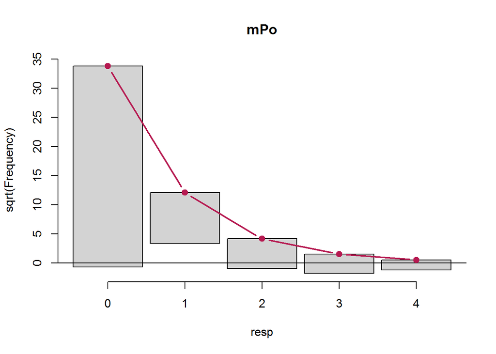

```r
countreg::rootogram(mPo)
```

The red line shows square root of fitted Poisson frequency.  
“Hanging” from each point on the red line is a bar, the height of which represents the residuals: difference between expected and observed counts.  
A bar hanging below 0 indicates underfitting. A bar hanging above 0 indicates overfitting.  
The counts are transformed with a square root transformation to prevent smaller counts from getting obscured and overwhelmed by larger counts.

Note underfitting for counts 2 and higher and overfitting for the 1 count.

Predicted probabilities of response equal from 0 to 6 by both races.

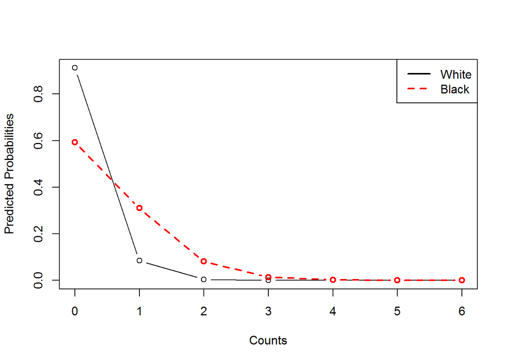

```r
predBlack<-sapply(0:6,function(z)
  dpois(z,predict(mPo,newdata=data.frame(race=c("black")),type="response")))

predWhite<-sapply(0:6,function(z)
  dpois(z,predict(mPo,newdata=data.frame(race=c("white")),type="response")))

plot(0:6,predWhite,type="b",ylab="Predicted Probabilities",xlab="Counts")
points(0:6,predBlack,col="red",type="b",lty=2,lwd=2)
legend("topright",legend=c("White","Black"),lty=c(1,2),col=c("black","red"),lwd=2)
```

**Draw conclusions from the results**.

### 3.2.3 Negative binomial regression

Fit negative binomial model using `glm.nb()` from `MASS`.

```r
mNb <- glm.nb(resp ~ race, data=victim)
summary(mNb)
```

```
##
## Call:
## glm.nb(formula = resp ~ race, data = victim, init.theta = 0.2023119205,
##     link = log)
##
## Deviance Residuals:
##     Min       1Q   Median       3Q      Max
## -0.7184  -0.3899  -0.3899  -0.3899   3.5072
##
## Coefficients:
##             Estimate Std. Error z value Pr(>|z|)
## (Intercept)  -2.3832     0.1172 -20.335  < 2e-16 ***
## raceblack     1.7331     0.2385   7.268 3.66e-13 ***
## ---
## Signif. codes:  0 '***' 0.001 '**' 0.01 '*' 0.05 '.' 0.1 ' ' 1
##
## (Dispersion parameter for Negative Binomial(0.2023) family taken to be 1)
##
##     Null deviance: 471.57  on 1307  degrees of freedom
## Residual deviance: 412.60  on 1306  degrees of freedom
## AIC: 1001.8
##
## Number of Fisher Scoring iterations: 1
##
##
##               Theta:  0.2023
##           Std. Err.:  0.0409
##
##  2 x log-likelihood:  -995.7980
```

Coefficients are the same as in Poisson regression. But the standard error for the race coefficient is larger.  
Also notice the estimate of the dispersion parameter $\theta$.

```r
(theta<-mNb$theta)
```

```
## [1] 0.2023119
```

With such parameter $\theta$ variance of counts is calculated as

$$\sigma^2=\mu+\frac{\mu^2}{\theta}$$

Compare again sample and model means and variances.

```r
Mus<-sort(unique(predict(mNb,type="response")))
rbind(Sample=countMeans,Model=Mus)
```

```
##             white     black
## Sample 0.09225413 0.5220126
## Model  0.09225413 0.5220126
```

```r
rbind(Sample=countVariances,Model=Mus+Mus^2/mNb$theta)
```

```
##            white    black
## Sample 0.1552448 1.149829
## Model  0.1343220 1.868928
```

This time model variances are not obviously underestimated relative to sample variances.

Visualize the fit.

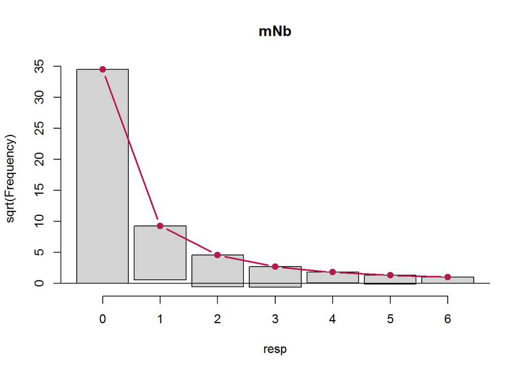

```r
countreg::rootogram(mNb)
```

This rootogram looks much better.

Plot predicted probabilities of response equal from 0 to 6 by both races.

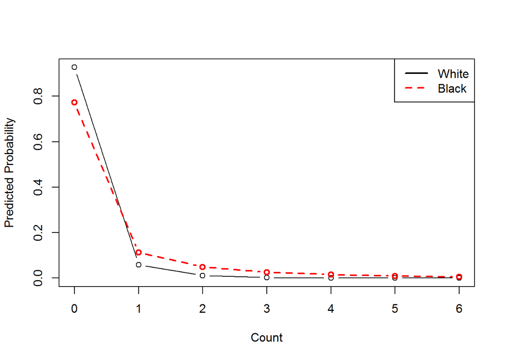

```r
mu<-predict(mPo,newdata=data.frame(race=c("black")),type="response")
predBlack<-sapply(0:6,function(z) dnbinom(z,mu=mu,size=mNb$theta))
mu<-predict(mPo,newdata=data.frame(race=c("white")),type="response")
predWhite<-sapply(0:6,function(z) dnbinom(z,mu=mu,size=mNb$theta))

plot(0:6,predWhite,type="b",xlab="Count",ylab="Predicted Probability")
points(0:6,predBlack,col="red",type="b",lty=2,lwd=2)
legend("topright",legend=c("White","Black"),lty=c(1,2),col=c("black","red"),lwd=2)
```

## 3.3 Demand for medical care by elderly

### 3.3.1 Data

Deb and Trivedi data `DebTrivedi.rda` and the description of this project can be downloaded [from here](https://www.jstatsoft.org/article/view/v027i08).

The data contain records on 4406 individuals, aged 66 and over, who are covered by Medicare, a public insurance program.

Originally the data were obtained from the US National Medical Expenditure Survey (NMES) for 1987/88.

The objective is to model the demand for medical care as captured by the number of physician/non-physician office and hospital outpatient visits by the covariates available for the patients.

```r
load(paste(dataPath,"DebTrivedi.rda",sep="/"))
dat <- DebTrivedi[, c(1, 6:8, 13, 15, 18)]
head(dat)
```

```
##   ofp hosp  health numchron gender school privins
## 1   5    1 average        2   male      6     yes
## 2   1    0 average        2 female     10     yes
## 3  13    3    poor        4 female     10      no
## 4  16    1    poor        2   male      3     yes
## 5   3    0 average        2 female      6     yes
## 6  17    0    poor        5 female      7      no
```

```r
dat$health<-as.factor(dat$health)
dat$gender<-as.factor(dat$gender)
dat$privins<-as.factor(dat$privins)
```

Use the number of physician office visits `ofp` as the dependent variable and as regressors use:

1. The health status variables:
- `hosp` (number of hospital stays),
- `health` (self-perceived health status),
- `numchron` (number of chronic conditions),
2. And socioeconomic variables, such as:
- `gender`,
- `school` (number of years of education),
- `privins` (private insurance indicator).

Observe the histogram of the response.

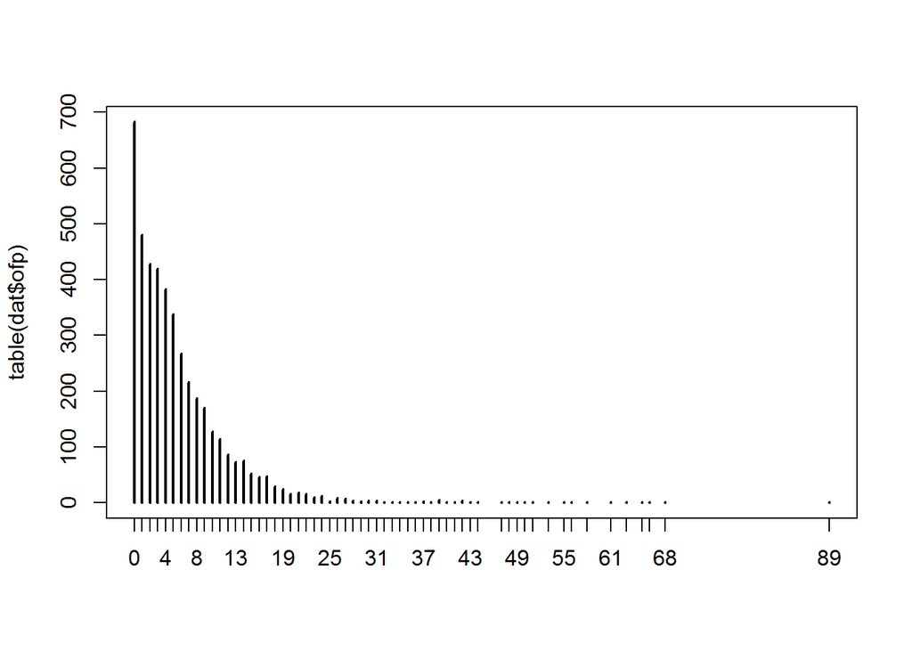

```r
plot(table(dat$ofp))
```

The plot shows significant number of zeros and high variance.

Prepare functions for visualization of the relationships between each predictor and the response [as here](https://www.jstatsoft.org/article/view/v027i08).

```r
clog <- function(x) log(x + 0.5) # Continuity corrected log
cfac <- function(x, breaks = NULL) { # make count variable a factor
 if(is.null(breaks)) breaks <- unique(quantile(x, 0:10/10))
 x <- cut(x, breaks, include.lowest = TRUE, right = FALSE)
 levels(x) <- paste(breaks[-length(breaks)], ifelse(diff(breaks) > 1,
 c(paste("-", breaks[-c(1, length(breaks))] - 1, sep = ""), "+"), ""),
 sep = "")
 return(x)
}
```

Plot the pairwise relationships.

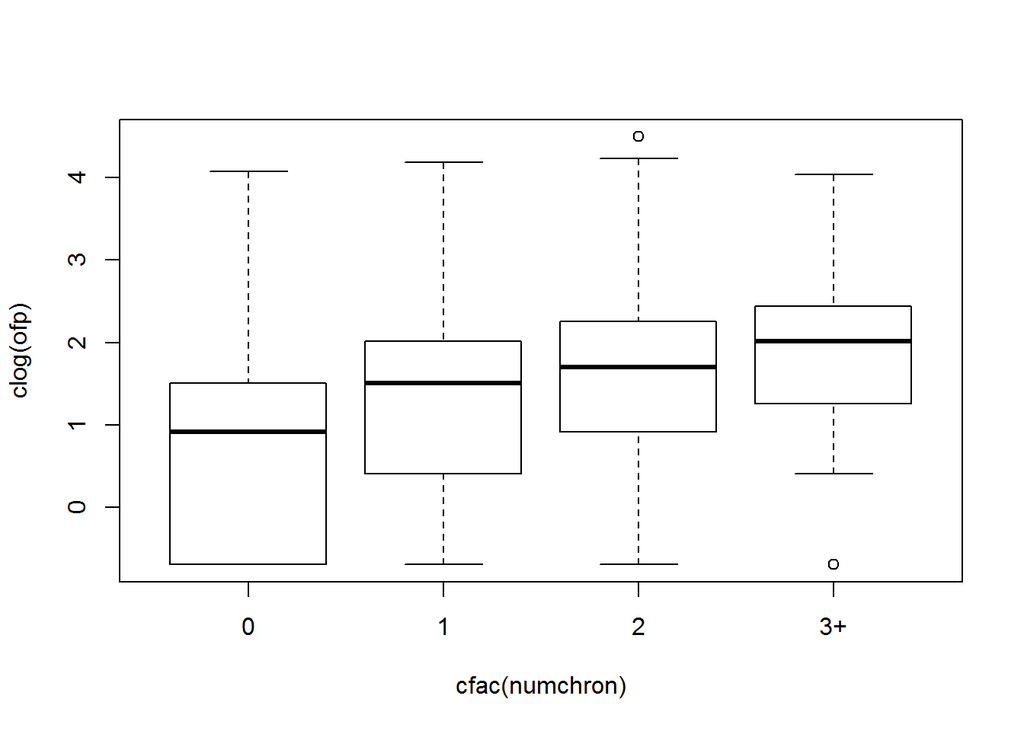

```r
plot(clog(ofp) ~ cfac(numchron), data = dat)
```

Number of visits increases with number of chronic conditions.

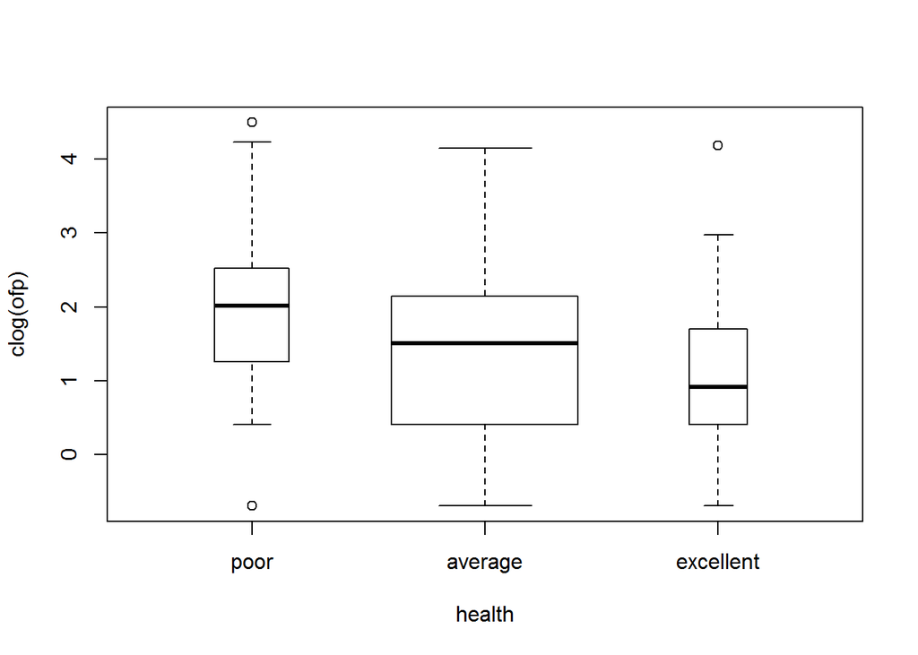

```r
plot(clog(ofp) ~ health, data = dat, varwidth = TRUE)
```

Number of visits decreases with better health.

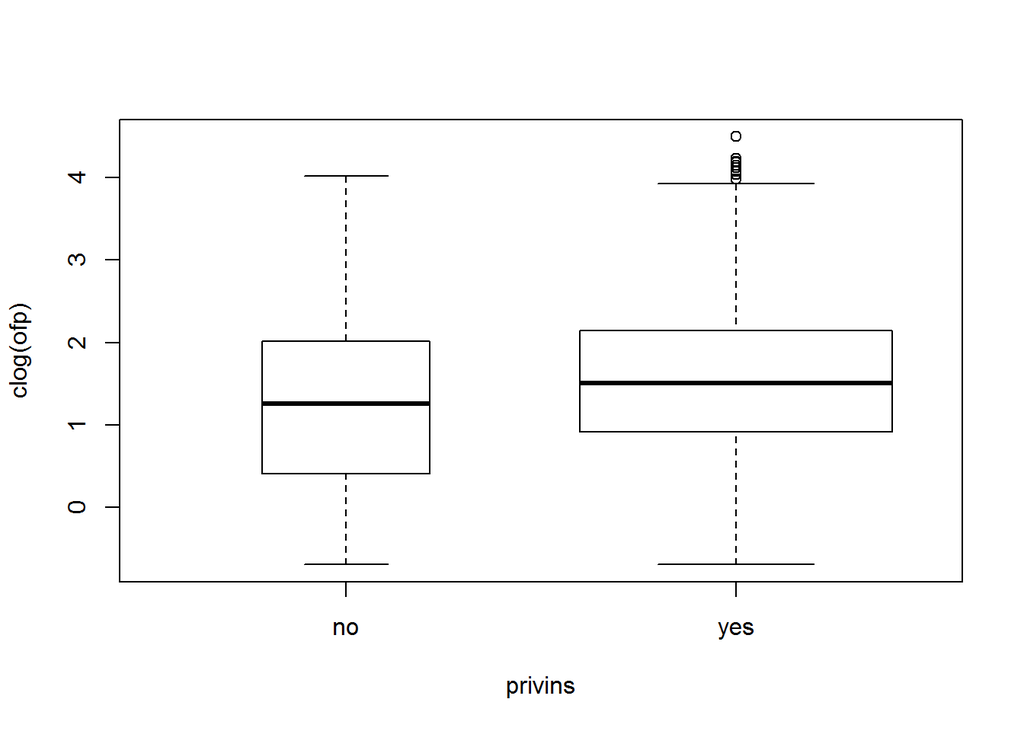

```r
plot(clog(ofp) ~ privins, data = dat, varwidth = TRUE)
```

Those who hold private insurance visit doctors slightly more often based on medians, but have fat tail on the upside.

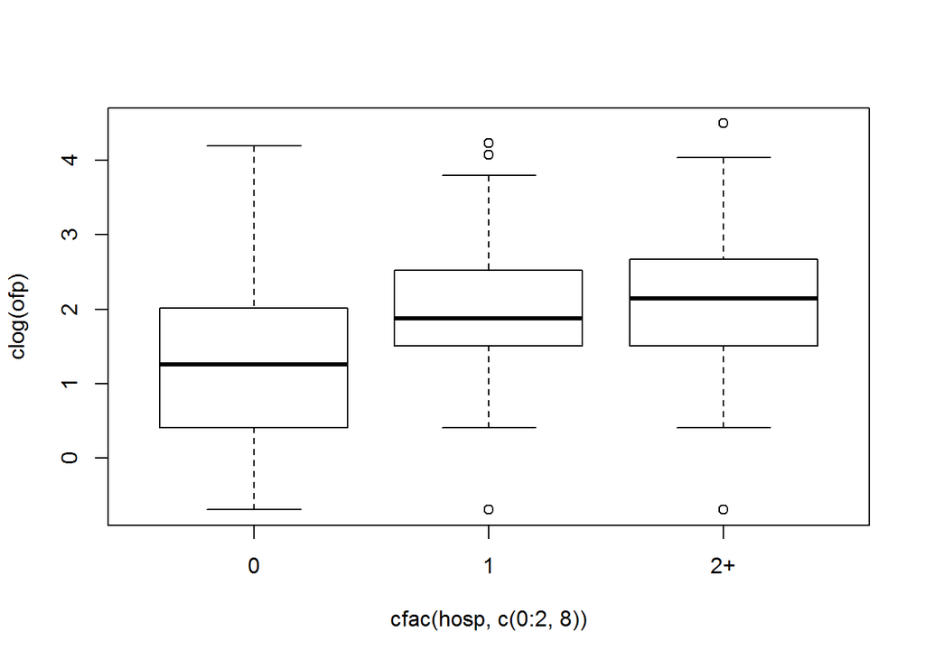

```r
plot(clog(ofp) ~ cfac(hosp, c(0:2, 8)), data = dat)
```

Number of hospital stays is positively correlated with number of visits to doctors.

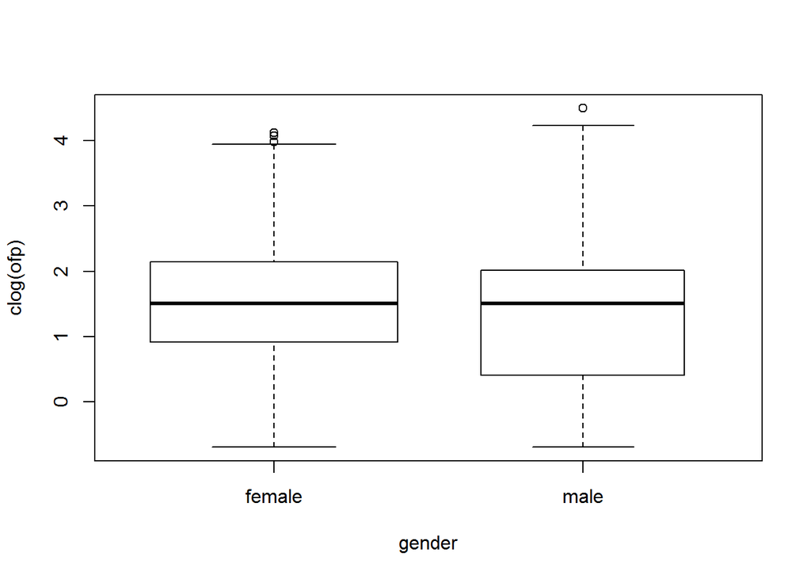

```r
plot(clog(ofp) ~ gender, data = dat, varwidth = TRUE)
```

Medians and upper quartiles are very similar between men and women. But men have lower 25% quartile, higher non-outlier maximum and longer tail of outliers on the upside.

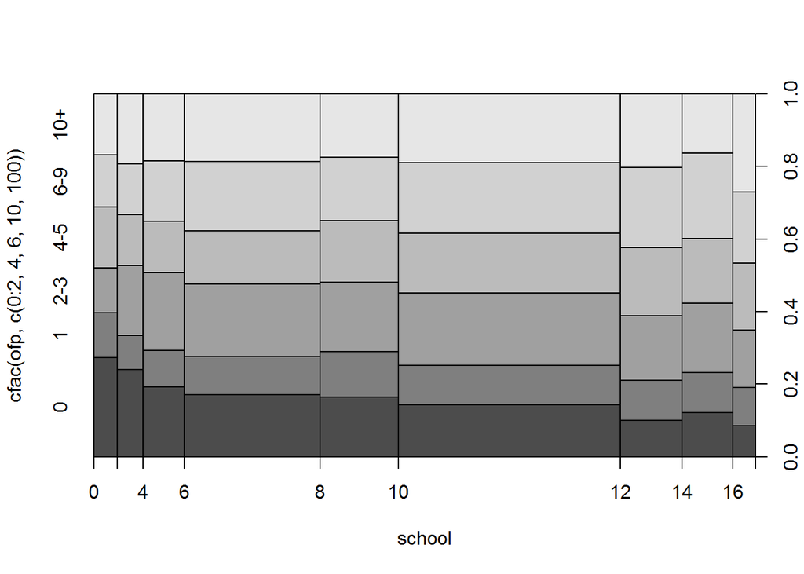

```r
plot(cfac(ofp, c(0:2, 4, 6, 10, 100)) ~ school, data = dat, breaks = 9)
```

With number of years of education the number of visits grows.

### 3.3.2 Poisson regression

```r
fm_pois <- glm(ofp ~ ., data = dat, family = poisson)
summary(fm_pois)
```

```
##
## Call:
## glm(formula = ofp ~ ., family = poisson, data = dat)
##
## Deviance Residuals:
##     Min       1Q   Median       3Q      Max
## -8.4055  -1.9962  -0.6737   0.7049  16.3620
##
## Coefficients:
##                  Estimate Std. Error z value Pr(>|z|)
## (Intercept)      1.028874   0.023785  43.258   <2e-16 ***
## hosp             0.164797   0.005997  27.478   <2e-16 ***
## healthpoor       0.248307   0.017845  13.915   <2e-16 ***
## healthexcellent -0.361993   0.030304 -11.945   <2e-16 ***
## numchron         0.146639   0.004580  32.020   <2e-16 ***
## gendermale      -0.112320   0.012945  -8.677   <2e-16 ***
## school           0.026143   0.001843  14.182   <2e-16 ***
## privinsyes       0.201687   0.016860  11.963   <2e-16 ***
## ---
## Signif. codes:  0 '***' 0.001 '**' 0.01 '*' 0.05 '.' 0.1 ' ' 1
##
## (Dispersion parameter for poisson family taken to be 1)
##
##     Null deviance: 26943  on 4405  degrees of freedom
## Residual deviance: 23168  on 4398  degrees of freedom
## AIC: 35959
##
## Number of Fisher Scoring iterations: 5
```

All Poisson coefficients are significant.

**Interpret signs and values of the coefficients**

```r
exp(coef(fm_pois))
```

```
##     (Intercept)            hosp      healthpoor healthexcellent
##       2.7979142       1.1791542       1.2818534       0.6962871
##        numchron      gendermale          school      privinsyes
##       1.1579362       0.8937583       1.0264877       1.2234649
```

Test for overdispersion.

```r
dispersiontest(fm_pois)
```

```
##
##  Overdispersion test
##
## data:  fm_pois
## z = 11.509, p-value < 2.2e-16
## alternative hypothesis: true dispersion is greater than 1
## sample estimates:
## dispersion
##   6.706192
```

This is clear sign of overdispersion.

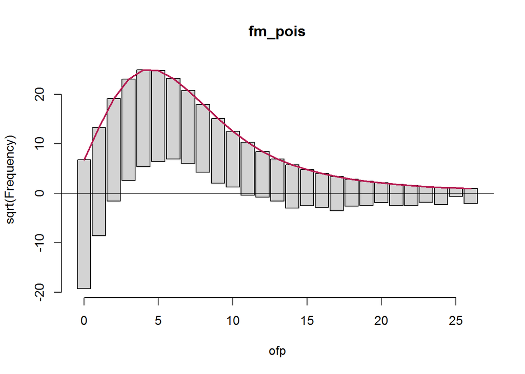

```r
countreg::rootogram(fm_pois)
```

Rootogram shows poor fit.

### 3.3.3 Quasi-Poisson regression

One way of dealing with over-dispersion is to use the mean regression function and the variance function from the Poisson GLM but to leave the dispersion parameter unrestricted.

Thus, dispersion is not assumed to be fixed at 1 but is estimated from the data.  
This leads to the same coefficient estimates as the standard Poisson model but inference is adjusted for over-dispersion.  
If estimated dispersion parameter is greater than 1 we conclude that there is overdispersion.

In R, the quasi-Poisson model with estimated dispersion parameter can also be fitted with the `glm()` function, simply setting `family = quasipoisson`.

```r
fm_qpois <- glm(ofp ~ ., data = dat, family = quasipoisson)
summary(fm_qpois)
```

```
##
## Call:
## glm(formula = ofp ~ ., family = quasipoisson, data = dat)
##
## Deviance Residuals:
##     Min       1Q   Median       3Q      Max
## -8.4055  -1.9962  -0.6737   0.7049  16.3620
##
## Coefficients:
##                  Estimate Std. Error t value Pr(>|t|)
## (Intercept)      1.028874   0.061594  16.704  < 2e-16 ***
## hosp             0.164797   0.015531  10.611  < 2e-16 ***
## healthpoor       0.248307   0.046211   5.373 8.13e-08 ***
## healthexcellent -0.361993   0.078476  -4.613 4.09e-06 ***
## numchron         0.146639   0.011860  12.364  < 2e-16 ***
## gendermale      -0.112320   0.033523  -3.351 0.000813 ***
## school           0.026143   0.004774   5.477 4.58e-08 ***
## privinsyes       0.201687   0.043661   4.619 3.96e-06 ***
## ---
## Signif. codes:  0 '***' 0.001 '**' 0.01 '*' 0.05 '.' 0.1 ' ' 1
##
## (Dispersion parameter for quasipoisson family taken to be 6.706254)
##
##     Null deviance: 26943  on 4405  degrees of freedom
## Residual deviance: 23168  on 4398  degrees of freedom
## AIC: NA
##
## Number of Fisher Scoring iterations: 5
```

The estimated dispersion is

```r
summary(fm_qpois)$dispersion
```

```
## [1] 6.706254
```

Which is a large number in comparison with 1: quasi-Poisson model was able to capture some overdispersion.

### 3.3.4 Negative binomial regression

Obtain negative binomial fit.

```r
fm_nbin <- glm.nb(ofp ~ ., data = dat)
summary(fm_nbin)
```

```
##
## Call:
## glm.nb(formula = ofp ~ ., data = dat, init.theta = 1.206603534,
##     link = log)
##
## Deviance Residuals:
##     Min       1Q   Median       3Q      Max
## -3.0469  -0.9955  -0.2948   0.2961   5.8185
##
## Coefficients:
##                  Estimate Std. Error z value Pr(>|z|)
## (Intercept)      0.929257   0.054591  17.022  < 2e-16 ***
## hosp             0.217772   0.020176  10.793  < 2e-16 ***
## healthpoor       0.305013   0.048511   6.288 3.23e-10 ***
## healthexcellent -0.341807   0.060924  -5.610 2.02e-08 ***
## numchron         0.174916   0.012092  14.466  < 2e-16 ***
## gendermale      -0.126488   0.031216  -4.052 5.08e-05 ***
## school           0.026815   0.004394   6.103 1.04e-09 ***
## privinsyes       0.224402   0.039464   5.686 1.30e-08 ***
## ---
## Signif. codes:  0 '***' 0.001 '**' 0.01 '*' 0.05 '.' 0.1 ' ' 1
##
## (Dispersion parameter for Negative Binomial(1.2066) family taken to be 1)
##
##     Null deviance: 5743.7  on 4405  degrees of freedom
## Residual deviance: 5044.5  on 4398  degrees of freedom
## AIC: 24359
##
## Number of Fisher Scoring iterations: 1
##
##
##               Theta:  1.2066
##           Std. Err.:  0.0336
##
##  2 x log-likelihood:  -24341.1070
```

Regression coefficients and standard errors of `fm_nbin` and `fm_qpois` are similar.  
We expect similar predictions and conclusions from both of them.

Negative binomial model is more theoretically solid and is based on formal likelihood function without any adjustments.  
From Negative binomial model we can calculate directly probability of number of zeros.

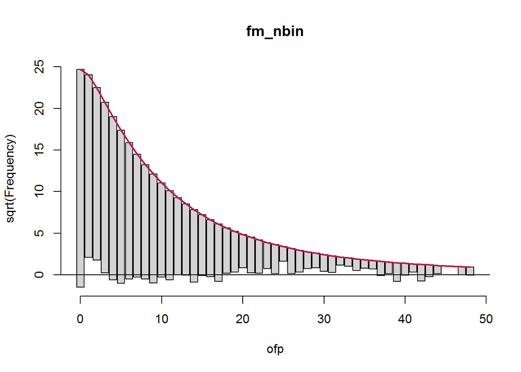

```r
countreg::rootogram(fm_nbin)
```

Negative binomial rootogram looks better than Poisson.

Calculate probability of zero count by negative binomial regression and compare it with the observed frequency.

(Skipped Code)

```r
head(probabil_0.nb)
```

```
##          1          2          3          4          5          6
## 0.11999833 0.11809681 0.03689403 0.09550012 0.13135285 0.06838122
```

Plot predicted probabilities of zero count and observed proportion of zeros.

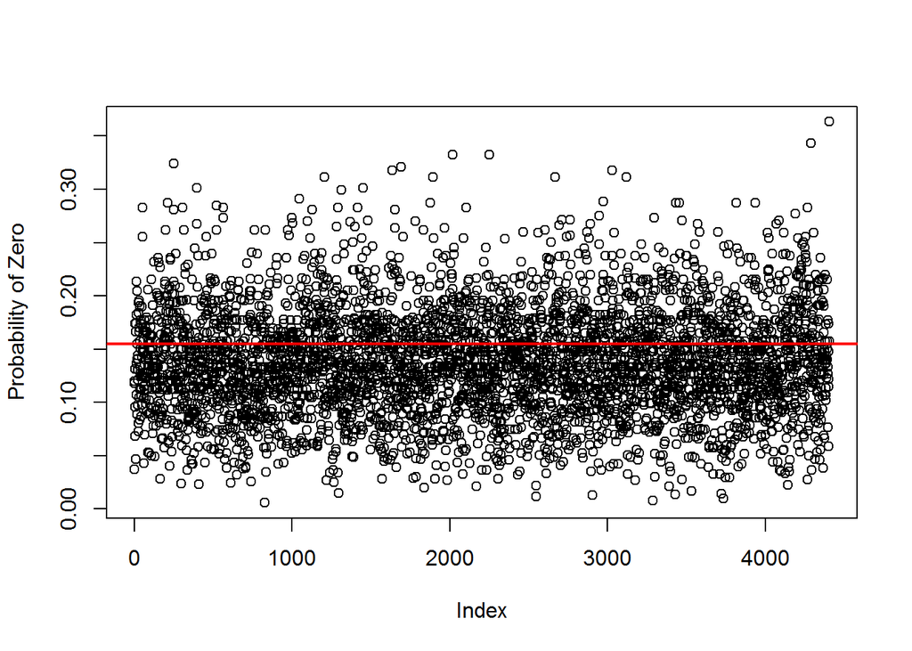

```r
obs0<-sum(dat$ofp==0)/length(dat$ofp)
plot(probabil_0.nb,ylab="Probability of Zero")
abline(h=obs0,col="red",lwd=2)
```

### 3.3.5 Hurdle and zero-inflated models

Often overdispersion is a result of increased number of zeros in the sample.  
Two following types of models are known to account for that.

#### 3.3.5.1 Hurdle model

Hurdle model will model the data as combination of two models:

1. Model producing only zeros;
2. And model producing only positive counts, so called **zero-truncated model**.

Hurdle model can be based on Poisson or on negative binomial distribution.

For the zero model part it is common to use logit link, but any binomial link is possible.

To fit hurdle model use function `hurdle()` from library `pscl`.

Fit hurdle model with negative binomial family and same parameter sets for zero part of the model and positive part of the model.

```r
fm_hurdle0 <- hurdle(ofp ~ ., data = dat, dist = "negbin")
summary(fm_hurdle0)
```

```
##
## Call:
## hurdle(formula = ofp ~ ., data = dat, dist = "negbin")
##
## Pearson residuals:
##     Min      1Q  Median      3Q     Max
## -1.1718 -0.7080 -0.2737  0.3196 18.0092
##
## Count model coefficients (truncated negbin with log link):
##                  Estimate Std. Error z value Pr(>|z|)
## (Intercept)      1.197699   0.058973  20.309  < 2e-16 ***
## hosp             0.211898   0.021396   9.904  < 2e-16 ***
## healthpoor       0.315958   0.048056   6.575 4.87e-11 ***
## healthexcellent -0.331861   0.066093  -5.021 5.14e-07 ***
## numchron         0.126421   0.012452  10.152  < 2e-16 ***
## gendermale      -0.068317   0.032416  -2.108   0.0351 *
## school           0.020693   0.004535   4.563 5.04e-06 ***
## privinsyes       0.100172   0.042619   2.350   0.0188 *
## Log(theta)       0.333255   0.042754   7.795 6.46e-15 ***
## Zero hurdle model coefficients (binomial with logit link):
##                  Estimate Std. Error z value Pr(>|z|)
## (Intercept)      0.043147   0.139852   0.309 0.757688
## hosp             0.312449   0.091437   3.417 0.000633 ***
## healthpoor      -0.008716   0.161024  -0.054 0.956833
## healthexcellent -0.289570   0.142682  -2.029 0.042409 *
## numchron         0.535213   0.045378  11.794  < 2e-16 ***
## gendermale      -0.415658   0.087608  -4.745 2.09e-06 ***
## school           0.058541   0.011989   4.883 1.05e-06 ***
## privinsyes       0.747120   0.100880   7.406 1.30e-13 ***
## ---
## Signif. codes:  0 '***' 0.001 '**' 0.01 '*' 0.05 '.' 0.1 ' ' 1
##
## Theta: count = 1.3955
## Number of iterations in BFGS optimization: 16
## Log-likelihood: -1.209e+04 on 17 Df
```

Coefficients are similar to previous models. The zero sub-model does not need health assessment predictor. Log-likelihood has improved noticeably.

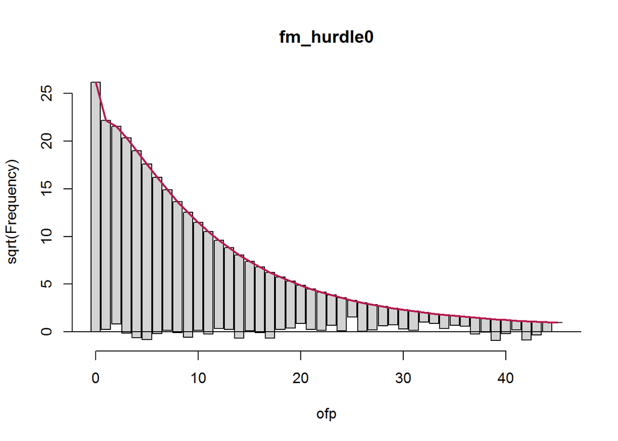

```r
countreg::rootogram(fm_hurdle0)
```

Note the effect of zero component of the model.

Same model with different sets for count and for zero sub-models:

```r
fm_hurdle <- hurdle(ofp ~ . | hosp + numchron + privins + school + gender,
                    data = dat, dist = "negbin")
summary(fm_hurdle)
```

```
##
## Call:
## hurdle(formula = ofp ~ . | hosp + numchron + privins + school +
##     gender, data = dat, dist = "negbin")
##
## Pearson residuals:
##     Min      1Q  Median      3Q     Max
## -1.1719 -0.7089 -0.2733  0.3229 17.9185
##
## Count model coefficients (truncated negbin with log link):
##                  Estimate Std. Error z value Pr(>|z|)
## (Intercept)      1.197699   0.058973  20.309  < 2e-16 ***
## hosp             0.211898   0.021396   9.904  < 2e-16 ***
## healthpoor       0.315958   0.048056   6.575 4.87e-11 ***
## healthexcellent -0.331861   0.066093  -5.021 5.14e-07 ***
## numchron         0.126421   0.012452  10.152  < 2e-16 ***
## gendermale      -0.068317   0.032416  -2.108   0.0351 *
## school           0.020693   0.004535   4.563 5.04e-06 ***
## privinsyes       0.100172   0.042619   2.350   0.0188 *
## Log(theta)       0.333255   0.042754   7.795 6.46e-15 ***
## Zero hurdle model coefficients (binomial with logit link):
##             Estimate Std. Error z value Pr(>|z|)
## (Intercept)  0.01594    0.13776   0.116 0.907881
## hosp         0.31843    0.09107   3.496 0.000471 ***
## numchron     0.54783    0.04358  12.571  < 2e-16 ***
## privinsyes   0.74572    0.10031   7.434 1.05e-13 ***
## school       0.05707    0.01193   4.785 1.71e-06 ***
## gendermale  -0.41915    0.08751  -4.790 1.67e-06 ***
## ---
## Signif. codes:  0 '***' 0.001 '**' 0.01 '*' 0.05 '.' 0.1 ' ' 1
##
## Theta: count = 1.3955
## Number of iterations in BFGS optimization: 16
## Log-likelihood: -1.209e+04 on 15 Df
```

This model differs insignificantly from the complete model.

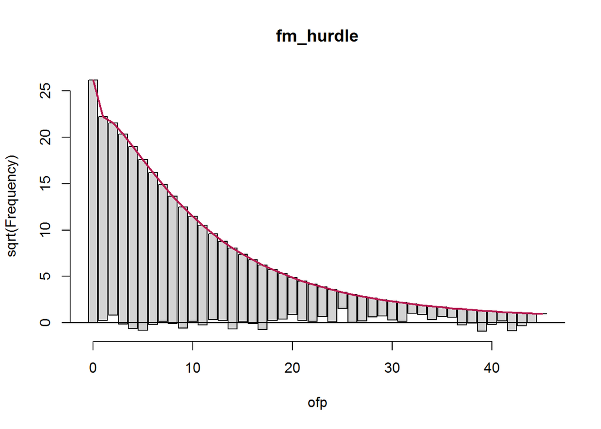

```r
countreg::rootogram(fm_hurdle)
```

#### 3.3.5.2 Zero-inflated model

Zero-inflated model is a mix of a zero-producing model and regular Poisson or negative binomial model.  
The zero-making part is logistic.

Equation of zero-inflated Poisson model (ZIP) is

$$P(y_i=0)= p_i+(1-p_i)e^{-\lambda_i},$$
$$P(y_i=k)= (1-p_i)\frac{e^{-\lambda_i} \lambda_i^k}{k!},$$
or
$$\mu_i=p_i \times 0+(1-p_i)e^{\beta_0+\beta_1x_1+\ldots}.$$

In general, for Poisson or negative binomial model

$$P(y_i=0)= p_i+(1-p_i)P(C=0),$$
$$P(y_i=k)= (1-p_i)P(C=k),$$
where $P(C=k)$ is probability of count $C$ equal to $k$ given by the count component model.

Function for fitting zero-inflated model is`zeroinf()`, library `pscl`.

Fit zero-inflated negative binomial model with identical complete sets of predictors for both sub-models and with different sets.

```r
fm_zinb0 <- zeroinfl(ofp ~ ., data = dat, dist = "negbin")
summary(fm_zinb0)
```

```
##
## Call:
## zeroinfl(formula = ofp ~ ., data = dat, dist = "negbin")
##
## Pearson residuals:
##     Min      1Q  Median      3Q     Max
## -1.1966 -0.7097 -0.2784  0.3256 17.7661
##
## Count model coefficients (negbin with log link):
##                  Estimate Std. Error z value Pr(>|z|)
## (Intercept)      1.193466   0.056737  21.035  < 2e-16 ***
## hosp             0.201214   0.020392   9.867  < 2e-16 ***
## healthpoor       0.287190   0.045940   6.251 4.07e-10 ***
## healthexcellent -0.313540   0.062977  -4.979 6.40e-07 ***
## numchron         0.128955   0.011938  10.802  < 2e-16 ***
## gendermale      -0.080093   0.031035  -2.581  0.00986 **
## school           0.021338   0.004368   4.886 1.03e-06 ***
## privinsyes       0.126815   0.041687   3.042  0.00235 **
## Log(theta)       0.394731   0.035145  11.231  < 2e-16 ***
##
## Zero-inflation model coefficients (binomial with logit link):
##                 Estimate Std. Error z value Pr(>|z|)
## (Intercept)     -0.06354    0.27668  -0.230  0.81837
## hosp            -0.81760    0.43875  -1.863  0.06240 .
## healthpoor       0.10178    0.44071   0.231  0.81735
## healthexcellent  0.10488    0.30965   0.339  0.73484
## numchron        -1.24630    0.17918  -6.956 3.51e-12 ***
## gendermale       0.64937    0.20046   3.239  0.00120 **
## school          -0.08481    0.02676  -3.169  0.00153 **
## privinsyes      -1.15808    0.22436  -5.162 2.45e-07 ***
## ---
## Signif. codes:  0 '***' 0.001 '**' 0.01 '*' 0.05 '.' 0.1 ' ' 1
##
## Theta = 1.484
## Number of iterations in BFGS optimization: 31
## Log-likelihood: -1.209e+04 on 17 Df
```

This model questions significance of hospital stays and health assessment variables for the zero component.

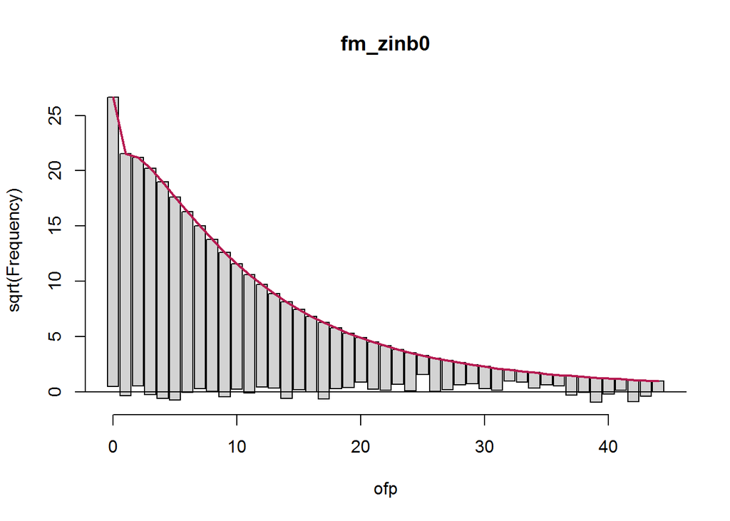

```r
countreg::rootogram(fm_zinb0)
```

The rootogram shows significant zero-inflation and overall good fit.

Fit the model with different sets of predictors for zero-inflated and count components.

```r
fm_zinb <- zeroinfl(ofp ~ . | numchron + privins + school + gender,
                    data = dat, dist = "negbin")
summary(fm_zinb)
```

```
##
## Call:
## zeroinfl(formula = ofp ~ . | numchron + privins + school + gender,
##     data = dat, dist = "negbin")
##
## Pearson residuals:
##     Min      1Q  Median      3Q     Max
## -1.1980 -0.7081 -0.2728  0.3265 18.0135
##
## Count model coefficients (negbin with log link):
##                  Estimate Std. Error z value Pr(>|z|)
## (Intercept)      1.197683   0.056576  21.169  < 2e-16 ***
## hosp             0.211311   0.020326  10.396  < 2e-16 ***
## healthpoor       0.285186   0.045147   6.317 2.67e-10 ***
## healthexcellent -0.322441   0.060206  -5.356 8.53e-08 ***
## numchron         0.128995   0.011933  10.810  < 2e-16 ***
## gendermale      -0.084300   0.031027  -2.717  0.00659 **
## school           0.021488   0.004365   4.922 8.55e-07 ***
## privinsyes       0.117544   0.041631   2.823  0.00475 **
## Log(theta)       0.395647   0.035368  11.187  < 2e-16 ***
##
## Zero-inflation model coefficients (binomial with logit link):
##             Estimate Std. Error z value Pr(>|z|)
## (Intercept) -0.07043    0.26763  -0.263  0.79242
## numchron    -1.24725    0.17852  -6.987 2.82e-12 ***
## privinsyes  -1.24289    0.22153  -5.611 2.02e-08 ***
## school      -0.08394    0.02646  -3.172  0.00151 **
## gendermale   0.55588    0.19808   2.806  0.00501 **
## ---
## Signif. codes:  0 '***' 0.001 '**' 0.01 '*' 0.05 '.' 0.1 ' ' 1
##
## Theta = 1.4853
## Number of iterations in BFGS optimization: 27
## Log-likelihood: -1.209e+04 on 14 Df
```

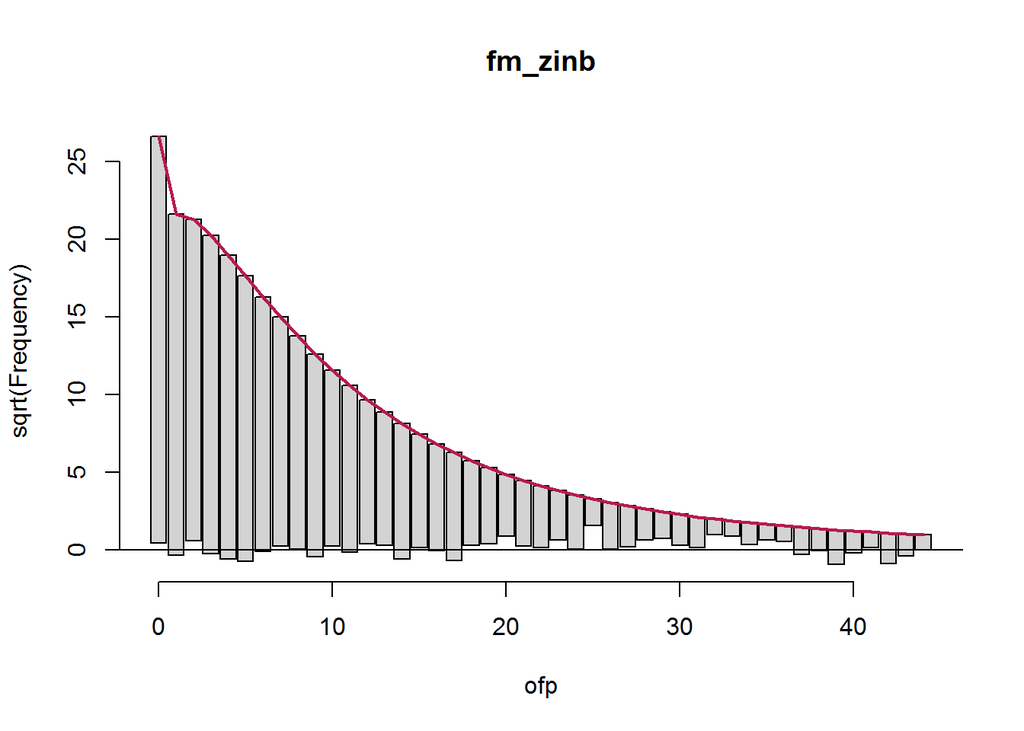

```r
countreg::rootogram(fm_zinb)
```

Calculate predicted probabilities of count zero by the zero-inflated model.  
Probabilities of different counts are returned by `predict()` with type “prob”.

```r
predZINB<-predict(fm_zinb,type="prob")
head(predZINB[,1:6])
```

```
##            0          1          2          3          4          5
## 1 0.10743293 0.10144048 0.10178459 0.09548181 0.08645112 0.07658059
## 2 0.09954368 0.10713153 0.10663433 0.09923038 0.08912584 0.07831784
## 3 0.02584425 0.03160332 0.03615858 0.03867746 0.03993152 0.04033406
## 4 0.09334668 0.07997699 0.08343008 0.08136697 0.07659228 0.07053747
## 5 0.11251331 0.11604049 0.11347502 0.10374301 0.09154377 0.07903088
## 6 0.05041455 0.06368642 0.06868764 0.06925931 0.06740454 0.06417978
```

Probabilities of count zero are in the first column.

```r
predZINB<-predZINB[,1]
head(predZINB)
```

```
##          1          2          3          4          5          6
## 0.10743293 0.09954368 0.02584425 0.09334668 0.11251331 0.05041455
```

Calculate predicted probabilities of count zero by the zero component of the model.

Probabilities of count zero are calculated by formula:

$$P(N_{zinb}=0)=P_{zero}(0)+(1-P_{zero}(0))P_{count}(0),$$
where $P(N_{zinb}=0)$ is the probability of zero count given by model ZINB, $P_{zero}(0)$ is probability of zero count given by the zero component of ZINB and $P_{count}(0)$ is probability of zero count given by count component of ZINB.
For all other counts $k>0$ the formula is:
$$P(N_{zinb}=k)=(1-P_{zero}(0))P_{count}(k).$$

```r
predZero<-predict(fm_zinb,type="zero")
```

Predict probability of zero count by the count component of the model.

```r
dumPredictors<-data.frame(hosp=dat$hosp,
                         healthpoor=dat$health=="poor",
                         healthexcellent=dat$health=="excellent",
                         numchron=dat$numchron,
                         gendermale=dat$gender=="male",
                         school=dat$school,
                         privinsyes=dat$privins=="yes")
linPred<-fm_zinb$coefficients$count[1]+apply(dumPredictors,1,function(z) z%*%fm_zinb$coefficients$count[-1])
head(linPred)
```

```
## [1] 1.829155 1.788095 2.847659 2.049877 1.702144 2.278259
```

```r
predCount<-dnbinom(0,mu=exp(linPred),size=fm_zinb$theta)
```

Or use alternative way by formula:

$$P(N_{zinb}=0)=P_{zero}(0)+(1-P_{zero}(0))P_{count}(0),$$
or
$$P_{count}(0)=\frac{P(N_{zinb}=0)-P_{zero}(0)}{(1-P_{zero}(0))}.$$

```r
predCount1<-(predZINB-predZero)/(1-predZero)
head(cbind(predCount,predCount1))
```

```
##    predCount predCount1
## 1 0.08655852 0.08655852
## 2 0.09090992 0.09090992
## 3 0.02317250 0.02317250
## 4 0.06607080 0.06607080
## 5 0.10060861 0.10060861
## 6 0.04945207 0.04945207
```

#### 3.3.5.3 Comparison of the models

For comparison look at coefficients of all models:

```r
fm <- list("ML-Pois" = fm_pois, "Quasi-Pois" = fm_qpois, "NB" = fm_nbin,
           "Hurdle-NB" = fm_hurdle, "ZINB" = fm_zinb)
sapply(fm, function(x) round(coef(x)[1:8],3))
```

```
##                 ML-Pois Quasi-Pois     NB Hurdle-NB   ZINB
## (Intercept)       1.029      1.029  0.929     1.198  1.198
## hosp              0.165      0.165  0.218     0.212  0.211
## healthpoor        0.248      0.248  0.305     0.316  0.285
## healthexcellent  -0.362     -0.362 -0.342    -0.332 -0.322
## numchron          0.147      0.147  0.175     0.126  0.129
## gendermale       -0.112     -0.112 -0.126    -0.068 -0.084
## school            0.026      0.026  0.027     0.021  0.021
## privinsyes        0.202      0.202  0.224     0.100  0.118
```

There are some differences, especially between the GLMs and the zero-augmented models.  
However, the zero-augmented models have to be interpreted slightly differently: the GLMs (Poisson and negative binomial) have the same linear predictors, but zero-augmentation changes them.  
Overall, the estimated linear predictors seem consistent.

The standard errors are also similar.

```r
cbind("ML-Pois" = sqrt(diag(vcov(fm_pois))),"Adj-Pois" = sqrt(diag(sandwich(fm_pois))),sapply(fm[-1], function(x) round(sqrt(diag(vcov(x)))[1:8],3)))
```

```
##                     ML-Pois    Adj-Pois Quasi-Pois    NB Hurdle-NB  ZINB
## (Intercept)     0.023784601 0.064529808      0.062 0.055     0.059 0.057
## hosp            0.005997367 0.021945186      0.016 0.020     0.021 0.020
## healthpoor      0.017844531 0.054021990      0.046 0.049     0.048 0.045
## healthexcellent 0.030303905 0.077448586      0.078 0.061     0.066 0.060
## numchron        0.004579677 0.012907865      0.012 0.012     0.012 0.012
## gendermale      0.012945146 0.035343487      0.034 0.031     0.032 0.031
## school          0.001843329 0.005084002      0.005 0.004     0.005 0.004
## privinsyes      0.016859826 0.043128006      0.044 0.039     0.043 0.042
```

The only model that does not fit general pattern is Poisson, but it is not appropriate anyway.

Looking at the log likelihood functions helps distinguishing the models better.

```r
rbind(logLik = sapply(fm, function(x) round(logLik(x), digits = 0)),Df = sapply(fm, function(x) attr(logLik(x), "df")))
```

```
##        ML-Pois Quasi-Pois     NB Hurdle-NB   ZINB
## logLik  -17972         NA -12171    -12090 -12094
## Df           8          8      9        15     14
```

For quasi-Poisson log likelihood function cannot be calculated directly.  
Poisson model drops out of the competition.  
Negative binomial is a significant improvement, but both zero augmented models provide even better and almost same fits.

Finally, check the quality of predicting numbers of zeros by comparison observed and predicted numbers.

```r
round(c("Obs" = sum(dat$ofp < 1),
"ML-Pois" = sum(dpois(0, fitted(fm_pois))),
"NB" = sum(dnbinom(0, mu = fitted(fm_nbin), size = fm_nbin$theta)),
"NB-Hurdle" = sum(predict(fm_hurdle, type = "prob")[,1]),
"ZINB" = sum(predict(fm_zinb, type = "prob")[,1])))
```

```
##       Obs   ML-Pois        NB NB-Hurdle      ZINB
##       683        47       608       683       707
```

Obviously, Poisson model drastically underestimates the number of zeros.  
Other models do a much better job, especially the two zero-augmented models.